# Chapter 15 - Multivariate Models

## 15. Multivariate Models

Review of notation from linear algebra:

- If $x$ and $y$ are vectors, then $x^T y = \sum_j x_j y_j$.
- If $A$ is a matrix then $\text{det}(A)$ denotes the determinant of $A$, $A^T$ denotes the transpose of A, and $A^{-1}$ denotes the inverse of $A$ (if the inverse exists).
- The trace of a square matrix $A$, denoted by $\text{tr}(A)$, is the sum of its diagonal elements.
- The trace satisfies $\text{tr}(AB) = \text{tr}(BA)$ and $\text{tr}(A + B) = \text{tr}(A) + \text{tr}(B)$.
- The trace satisfies $\text{tr}(a) = a$ if $a$ is a scalar.
- A matrix $\Sigma$ is positive definite if $x^T \Sigma x > 0$ for all non-zero vectors $x$.
- If a matrix $\Sigma$ is symmetric and positive definite, there exists a matrix $\Sigma^{1/2}$, called the square root of $\Sigma$, with the following properties:
  - $\Sigma^{1/2}$ is symmetric
  - $\Sigma = \Sigma^{1/2} \Sigma^{1/2}$
  - $\Sigma^{1/2} \Sigma^{-1/2} = \Sigma^{-1/2} \Sigma^{1/2} = I$ where $\Sigma^{-1/2} = (\Sigma^{1/2})^{-1}$.

### 15.1 Random Vectors

Multivariate models involve a random vector $X$ of the form

$$X = \begin{pmatrix} X_1 \\ \vdots \\ X_k \end{pmatrix}$$

The mean of a random vector $X$ is defined by

$$\mu = \begin{pmatrix} \mu_1 \\ \vdots \\ mu_k \end{pmatrix} = \begin{pmatrix} \mathbb{E}(X_1) \\ \vdots \\ \mathbb{E}(X_k) \end{pmatrix} $$

The covariance matrix $\Sigma$ is defined to be

$$\Sigma = \mathbb{V}(X) = \begin{pmatrix} \mathbb{V}(X_1) & \text{Cov}(X_1, X_2) & \cdots & \text{Cov}(X_1, X_k) \\ \text{Cov}(X_2, X_1) & \mathbb{V}(X_2) & \cdots & \text{Cov}(X_2, X_k) \\ \vdots & \vdots & \ddots & \vdots \\ \text{Cov}(X_k, X_1) & \text{Cov}(X_k, X_2) & \cdots & \mathbb{V}(X_k) \end{pmatrix}$$

This is also called the variance matrix or the variance-covariance matrix.

**Theorem 15.1**. Let $a$ be a vector of length $k$ and let $X$ be a random vector of the same length with mean $\mu$ and variance $\Sigma$. Then $\mathbb{E}(a^T X) = a^T\mu$ and $\mathbb{V}(a^T X) = a^T \Sigma a$. If $A$ is a matrix with $k$ columns then $\mathbb{E}(AX) = A\mu$ and $\mathbb{V}(AX) = A \Sigma A^T$.

Now suppose we have a random sample of $n$ vectors:

$$ \begin{pmatrix}X_{11} \\ X_{21} \\ \vdots \\ X_{k1} \end{pmatrix}, \; \begin{pmatrix}X_{21} \\ X_{22} \\ \vdots \\ X_{k2} \end{pmatrix}, \; \cdots , \; \begin{pmatrix}X_{1n} \\ X_{2n} \\ \vdots \\ X_{kn} \end{pmatrix} $$

The sample mean $\overline{X}$ is a vector defined by

$$\overline{X} = \begin{pmatrix} \overline{X}_1 \\ \vdots \\ \overline{X}_k \end{pmatrix}$$

where $\overline{X}_i = n^{-1} \sum_{j = 1}^n X_{ij}$. The sample variance matrix is

$$ S = \begin{pmatrix} s_{11} & s_{12} & \cdots & s_{1k} \\ s_{12} & s_{22} & \cdots & s_{2k} \\ \vdots & \vdots & \ddots & \vdots \\ s_{1k} & s_{2k} & \cdots & s_{kk} \end{pmatrix} $$

where

$$s_{ab} = \frac{1}{n - 1} \sum_{j = 1}^n (X_{aj} - \overline{X}_a) (X_{bj} - \overline{X}_b)$$

It follows that $\mathbb{E}(\overline{X}) = \mu$ and $\mathbb{E}(S) = \Sigma$.

### 15.2 Estimating the Correlation

Consider $n$ data points from a bivariate distribution

$$ \begin{pmatrix} X_{11} \\ X_{21}\end{pmatrix}, \; \begin{pmatrix} X_{12} \\ X_{22}\end{pmatrix}, \; \cdots \; \begin{pmatrix} X_{1n} \\ X_{1n}\end{pmatrix} $$

Recall that the correlation between $X_1$ and $X_2$ is

$$\rho = \frac{\mathbb{E}((X_1 - \mu) (X_2 - \mu_2))}{\sigma_1 \sigma_2}$$

The sample correlation (the plug-in estimator) is

$$\hat{\rho} = \frac{\sum_{i=1}^n (X_{1i} - \overline{X}_1)(X_{2i} - \overline{X}_2)}{s_1 s_2}$$

We can construct a confidence interval for $\rho$ by applying the delta method as usual. However, it turns out that we get a more accurate confidence interval by first constructing a confidence interval for a function $\theta = f(\rho)$ and then applying the inverse function $f^{-1}$. The method, due to Fisher, is as follows. Define

$$f(r) = \frac{1}{2} \left( \log(1 + r) - \log(1 - r)\right) $$

and let $\theta = f(\rho)$. The inverse of $f$ is

$$g(z) \equiv f^{-1}(z) = \frac{e^{2z} - 1}{e^{2z} + 1}$$

Now do the following steps:

**Approximate Confidence Interval for the Correlation**

1. Compute

$$\hat{\theta} = f(\hat{\rho}) = \frac{1}{2} \left( \log(1 + \hat{\rho}) - \log(1 - \hat{\rho})\right) $$

1. Compute the approximate standard error of $\hat{\theta}$ which can be shown to be

$$\hat{\text{se}}(\hat{\theta}) = \frac{1}{\sqrt{n - 3}} $$

1. An approximate $1 - \alpha$ confidence interval for $\theta = f(\rho)$ is

$$(a, b) \equiv \left(\hat{\theta} - \frac{z_{\alpha/2}}{\sqrt{n - 3}}, \; \hat{\theta} + \frac{z_{\alpha/2}}{\sqrt{n - 3}} \right)$$

1. Apply the inverse transformation $f^{-1}(z)$ to get a confidence interval for $\rho$:

$$ \left( \frac{e^{2a} - 1}{e^{2a} + 1}, \frac{e^{2b} - 1}{e^{2b} + 1} \right) $$

### 15.3 Multinomial

Review of Multinomial distribution: consider drawing a ball from an urn that has $n$ balls of $k$ colors. Let $p = (p_1, \dots, p_k)$ where $p_j \geq 0$ are the probabilities of drawing (with replacement) a ball of each color; $\sum_j p_j = 1$. Draw $n$ times and let $X = (X_1, \dots, X_n)$ where $X_j$ is the number of times that color $j$ appeared; so $\sum_k X_k = n$. We say $X$ has a Multinomial($n$, $p$) distribution. The probability function is

$$ f(x; p) = \binom{n}{x_1 \dots x_k} p_1^{x_1}\dots p_k^{x_k}$$

where

$$ \binom{n}{x_1 \dots x_k} = \frac{n!}{x_1! \dots x_k!} $$

**Theorem 15.2**. Let $X \sim \text{Multinomial}(n, p)$. Then the marginal distribution of $X_j$ is $X_j \sim \text{Binomial}(n, p_j)$. The mean and variance of $X$ are

$$\mathbb{E}(X) = \begin{pmatrix} np_1 \\ \vdots \\ np_k \end{pmatrix}$$

and

$$\mathbb{V}(X) = \begin{pmatrix} np_1(1 - p_1) & -np_1p_2 & \cdots & -np_1p_k \\ -np_1p_2 & np_2(1 - p_2) & \cdots & -np_2p_k \\ \vdots & \vdots & \ddots & \vdots \\ -np_1p_k & -np_2p_k & \cdots & -np_k(1 - p_k) \end{pmatrix}$$

**Proof**. That $X_j \sim \text{Bimomial}(n, p_j)$ follows easily. Hence $\mathbb{E}(X_j) = np_j$ and $\mathbb{V}(X_j) = np_j(1 - p_j)$.

To compute $\text{Cov}(X_i, X_j)$, notice that $X_i + X_j \sim \text{Binomial}(n, p_i + p_j)$, so $\mathbb{V}(X_i + X_j) = n (p_i + p_j) (1 - p_i - p_j)$. On the other hand, decomposing the sum of the random variables on the variance,

$$ \begin{align} \mathbb{V}(X_i + X_j) &= \mathbb{V}(X_i) + \mathbb{V}(X_j) + 2 \text{Cov}(X_i, X_j) \\ &= np_i(1 - p_i) + np_j(1 - p_j) + 2 \text{Cov}(X_i, X_j) \end{align} $$

Equating both expressions and isolating the covariance we get $\text{Cov}(X_i, X_j) = -np_ip_j$.

**Theorem 15.3**. The maximum likelihood estimator of $p$ is

$$\hat{p} = \begin{pmatrix} \hat{p}_1 \\ \vdots \\ \hat{p}_k \end{pmatrix} = \begin{pmatrix} \frac{X_1}{n} \\ \vdots \\ \frac{X_k}{n} \end{pmatrix} = \frac{X}{n} $$

**Proof**. The log-likelihood (ignoring a constant) is $\ell(p) = \sum_j X_j \log p_j$. When we maximize it we need to be careful to enforce the constraint that $\sum_j p_j = 1$. Using Lagrange multipliers, instead we maximize

$$A(p) = \sum_{j=1}^k X_j \log p_j + \lambda \left( \sum_{j=1}^k p_j - 1 \right)$$

But

$$\frac{\partial A(p)}{\partial p_j} = \frac{X_j}{p_j} + \lambda$$

Setting it to zero we get $\hat{p}_j = - X_j / \lambda$. Since $\sum_j \hat{p}_j = 1$ we get $\lambda = -n$ and so $\hat{p}_j = X_j / n$, which is our result.

Next we want the variance of the MLE. The direct approach is to compute the variance matrix of $\hat{p}$ directly: $\mathbb{V}(\hat{p}) = \mathbb{V}(X / n) = n^{-2} \mathbb{V}(X)$, so

$$\mathbb{V}(\hat{p}) = \frac{1}{n} \begin{pmatrix} p_1(1 - p_1) & -p_1p_2 & \cdots & -p_1p_k \\ -p_1p_2 & p_2(1 - p_2) & \cdots & -p_2p_k \\ \vdots & \vdots & \ddots & \vdots \\ -p_1p_k & -p_2p_k & \cdots & p_k(1 - p_k) \end{pmatrix}$$

### 15.4 Multivariate Normal

Let's recall the definition of the multivariate normal. Let

$$ Z = \begin{pmatrix} Z_1 \\ \vdots \\ Z_k \end{pmatrix} $$

where $Z_1, \dots, Z_k \sim N(0, 1)$ are independent. The density of $Z$ is

$$ f(z) = \frac{1}{(2\pi)^{k / 2}} \exp \left\{ -\frac{1}{2} \sum_{j=1}^k z_j^2 \right\} = \frac{1}{(2\pi)^{k / 2}} \exp \left\{ -\frac{1}{2} z^T z \right\}$$

The variance matrix of $Z$ is the identity matrix $I$. We write $Z \sim N(0, I)$ where it is understood that $0$ is a vector of $k$ zeroes. We say $Z$ has a standard multivariate Normal distribution.

More generally, a vector $X$ has a multivariate Normal distribution, denoted by $X \sim N(\mu, \Sigma)$, if its density is

$$ f(x; \mu, \Sigma) = \frac{1}{(2 \pi)^{k / 2} \text{det}(\Sigma)^{1/2}} \exp \left\{ -\frac{1}{2} (x - \mu)^T \Sigma^{-1} (x - \mu)\right\}$$

where $\mu$ is a vector of length $k$ and $\Sigma$ is a $k \times k$ symmetric, positive definite matrix. Then $\mathbb{E}(X) = \mu$ and $\mathbb{V}(X) = \Sigma$. Setting $\mu = 0$ and $\Sigma = I$ gives back the standard Normal.

**Theorem 15.4**. The following properties hold:

1. If $Z \sim N(0, 1)$ and $X = \mu + \Sigma^{1/2} Z$ then $X \sim N(\mu, \Sigma)$.
2. If $X \sim N(\mu, \Sigma)$, then $\Sigma^{-1/2}(X - \mu) \sim N(0, 1)$.
3. If $X \sim N(\mu, \Sigma)$ and $a$ is a vector with the same length as $X$, then $a^T X \sim N(a^T \mu, a^T \Sigma a)$.
4. Let $V = (X - \mu)^T \Sigma^{-1} (X - \mu)$. Then $V \sim \xi_k^2$.

Suppose we partition a random Normal vector $X$ into two parts $X = (X_a, X_b)$. We can similarly partition the mean $\mu = (\mu_a, \mu_b)$ and the variance

$$\Sigma = \begin{pmatrix} \Sigma_{aa} & \Sigma_{ab} \\ \Sigma_{ba} & \Sigma_{bb} \end{pmatrix}$$

**Theorem 15.5**. Let $X \sim N(\mu, \Sigma)$. Then:

1. The marginal distribution of $X_a$ is $X_a \sim N(\mu_a, \Sigma_{aa})$.
2. The conditional distribution of $X_b$ given $X_a = x_a$ is

$$ X_b | X_a = x_a \sim N(\mu(x_a), \Sigma(x_a))$$

where

$$ \begin{align} \mu(x_a) &= \mu_b + \Sigma_{ba} \Sigma_{aa}^{-1} (x_a - \mu_a) \\ \Sigma(x_a) &= \Sigma_{bb} - \Sigma_{ba}\Sigma_{aa}^{-1}\Sigma_{ab} \end{align} $$

**Theorem 15.6**. Given a random sample of size $n$ from a $N(\mu, \Sigma)$, the log-likelihood (up to a constant not depending on $\mu$ or $\Sigma$) is given by

$$\ell(\mu, \Sigma) = -\frac{n}{2} (\overline{X} - \mu)^T \Sigma^{-1} (\overline{X} - \mu) - \frac{n}{2} \text{tr} \left( \Sigma^{-1}S \right) - \frac{n}{2} \log \text{det} \left( \Sigma \right) $$

The MLE is

$$ \hat{\mu} = \overline{X} \quad \text{and} \quad \hat{\Sigma} = \left( \frac{n - 1}{n} \right) S$$

### 15.5 Appendix

**Proof of Theorem 15.6**. Let the $i$-th random vector be $X^i$. The log-likelihood is

$$\ell(\mu, \Sigma) = \sum_{i = 1}^k f(X^i; \mu, \Sigma) = -\frac{kn}{2} \log ( 2\pi ) - \frac{n}{2} \log \text{det} \left( \Sigma \right) - \frac{1}{2} \sum_{i=1}^k (X^i - \mu)^T \Sigma^{-1} (X^i - \mu) $$

Now,

$$ \begin{align} \sum_{i=1}^k (X^i - \mu)^T \Sigma^{-1} (X^i - \mu) &= \sum_{i=1}^k \left[ (X^i - \overline(X)) + (\overline{X} - \mu) \right]^T \Sigma^{-1} \left[(X^i - \overline{X}) + (\overline{X} - \mu) \right] \\ &= \sum_{i=1}^k [(X^i - \overline{X})^T\Sigma^{-1}(X^i - \overline{X})] + n (\overline{X} - \mu)^T \Sigma^{-1} (\overline{X} - \mu) \end{align} $$

since $\sum_i (X^i - \overline{X}) \Sigma^{-1} (\overline{X} - \mu) = 0$. Also, $(X^i - \mu)^T \Sigma^T (X^i - \mu)$ is a scalar, so

$$ \begin{align} \sum_{i=1}^k (X^i - \mu)^T \Sigma^{-1} (X^i - \mu) &= \sum_{i=1}^k \text{tr} \left[ (X^i - \mu)^T \Sigma^{-1} (X^i - \mu)\right] \\ &= \sum_{i=1}^k \text{tr} \left[ \Sigma^{-1} (X^i - \mu) (X^i - \mu)^T \right] \\ &= \text{tr} \left[ \Sigma^{-1} \sum_{i=1}^k (X^i - \mu) (X^i - \mu) ^T \right] \\ &= n \; \text{tr} \left[ \Sigma^{-1} S\right] \end{align} $$

so the conclusion follows.

### 15.6 Exercises

**Exercise 15.6.1**. Prove Theorem 15.1.

Let $a$ be a vector of length $k$ and let $X$ be a random vector of the same length with mean $\mu$ and variance $\Sigma$. Then $\mathbb{E}(a^T X) = a^T\mu$ and $\mathbb{V}(a^T X) = a^T \Sigma a$. If $A$ is a matrix with $k$ columns then $\mathbb{E}(AX) = A\mu$ and $\mathbb{V}(AX) = A \Sigma A^T$.

**Solution**.

For the vector version of the theorem, we have:

$$\mathbb{E}(a^T X) = \mathbb{E}\left( \sum_{i=1}^k a_i X_i \right) = \sum_{i=1}^k a_i \mathbb{E}(X_i) = \sum_{i=1}^k a_i \mu_i = a^T \mu $$$$\mathbb{V}(a^T X) = \mathbb{V}\left( \sum_{i=1}^k a_i X_i \right) = \sum_{i=1}^k \sum_{j=1}^k a_i a_j \text{Cov} (X_i, X_j) = \sum_{i=1}^k a_i \left( \sum_{j=1}^k \text{Cov}(X_i, X_j) a_j \right) = \sum_{i=1}^k a_i \Big( \Sigma a \Big)_i = a^T \Sigma a$$

For the matrix version of the theorem, consider the $r$ rows of $A$ as vectors, separately, $a^1, \dots, a^k$:

$$ A = \begin{pmatrix} \cdots & a^1 & \cdots \\ \cdots & a^2 & \cdots \\ \vdots & \vdots & \vdots \\ \cdots & a^r & \cdots \end{pmatrix}$$

Then,

$$ \mathbb{E}(AX) = \begin{pmatrix} \mathbb{E}(a^1 X) \\ \mathbb{E}(a^2 X) \\ \vdots \\ \mathbb{E}(a^r X) \end{pmatrix} = \begin{pmatrix} a^1 \mu \\ a^2 \mu \\ \vdots \\ a^r \mu \end{pmatrix} = A\mu $$

Finally, looking at the $i$-th term of $AX$,

$$(AX)_i = \sum_{s=1}^k a_{is} X_s = a^i X$$

so, by the vector version of the theorem, $\mathbb{V}((AX)_i) = (a^i)^T \Sigma a^i$. Applying this to every element:

$$\mathbb{V}(AX) = \begin{pmatrix} \mathbb{V}((AX)_1) \\ \mathbb{V}((AX)_2) \\ \vdots \\ \mathbb{V}((AX)_r) \end{pmatrix} = \begin{pmatrix} \mathbb{V}(a^1 X) \\ \mathbb{V}(a^2 X) \\ \vdots \\ \mathbb{V}(a^r X) \end{pmatrix} = \begin{pmatrix} (a^1)^T \Sigma a^1 \\ (a^2)^T \Sigma a^2 \\ \vdots \\ (a^r)^T \Sigma a^r \end{pmatrix} = A \Sigma A^T$$

**Exercise 15.6.2**. Find the Fisher information matrix for the MLE of a Multinomial.

**Solution**.

The probability mass function for a Multinomial distribution is:

$$ f(X; p) = \binom{n}{X_1 \dots X_k} p_1^{X_1} \dots p_k^{X_k} = \frac{n!}{X_1! \dots X_k!} p_1^{X_1} \dots p_k^{X_k}$$

so the log-likelihood (ignoring a constant) is

$$ \ell_n(p) = \sum_{i=1}^k X_i \log p_i$$

The partial derivatives are:

$$ \begin{align} H_{ii} = \frac{\partial^2 \ell_n(p)}{\partial^2 p_i} &= -\frac{X_i}{p_i^2} \\ H_{ij} = \frac{\partial^2 \ell_n(p)}{\partial p_i \partial p_j} &= 0 \; \text{for } i \neq j \end{align} $$

so $\mathbb{E}(H_{ii}) = - n/p_i$, and the Fisher Information Matrix is:

$$I_n(p) = n \begin{pmatrix} \frac{1}{p_1} & 0 & \cdots & 0 \\ 0 & \frac{1}{p_2} & \cdots & 0 \\ \vdots & \vdots & \ddots & \vdots \\ 0 & 0 & \cdots & \frac{1}{p_k} \end{pmatrix}$$

Note, however, that the variance is *not* the inverse matrix of $I_n(p)$, and further, that, $\mathbb{V}(X)$ is not invertible.

**Exercise 15.6.3**. Prove Theorem 15.5.

Let $X \sim N(\mu, \Sigma)$. Then:

1. The marginal distribution of $X_a$ is $X_a \sim N(\mu_a, \Sigma_{aa})$.
2. The conditional distribution of $X_b$ given $X_a = x_a$ is

$$ X_b | X_a = x_a \sim N(\mu(x_a), \Sigma(x_a))$$

where

$$ \begin{align} \mu(x_a) &= \mu_b + \Sigma_{ba} \Sigma_{aa}^{-1} (x_a - \mu_a) \\ \Sigma(x_a) &= \Sigma_{bb} - \Sigma_{ba}\Sigma_{aa}^{-1}\Sigma_{ab} \end{align} $$

**Solution**.

The marginal distribution result is immediate: for any given sample drawn from the distribution, collect only the first $k$ dimensions of the sample vector, where $k$ is the number of dimensions of $X_a$. The resulting distribution will be multivariate normal, with mean and variance given by getting the first $k$ dimensions of $\mu$ and $\Sigma$.

For the conditional distribution result, let $A = -\Sigma_{ba} \Sigma_{aa}^{-1}$ and $z = x_b + A x_a$. We have:

$$\begin{align} \text{Cov}(z, x_a) &= \text{Cov}(x_b, x_a) + \text{Cov}(A x_a, x_a) \\ &= \Sigma_{ba} + A \mathbb{V}(x_a) \\ &= \Sigma_{ba} - \Sigma_{ba} \Sigma_{aa}^{-1} \Sigma_{aa} \\ &= 0 \end{align}$$

so $z$ and $x_a$ are uncorrelated (and since they are jointly normal, they are also independent). We then have:

$$\begin{align} \mathbb{E}(x_b | x_a) &= \mathbb{E}(z - A x_a | x_a) \\ &= \mathbb{E}(z | x_a) - \mathbb{E}(A x_a | x_a) \\ &= \mathbb{E}(z) - A x_a \\ &= \mu_b + A \mu_a - A x_a \\ &= \mu_b + \Sigma_{ba} \Sigma_{aa}^{-1} (x_a - \mu_a) \end{align}$$

For the covariance matrix,

$$\begin{align} \mathbb{V}(x_b | x_a) &= \mathbb{V}(z - A x_a | x_a) \\ &= \mathbb{V}(z | x_a) - \mathbb{V}(A x_a | x_a) - A \text{Cov}(z, -x_a) - \text{Cov}(z, -x_a) A^T \\ &= \mathbb{V}(z | x_a) - 0 - A \cdot 0 - 0 \cdot A \\ &= \mathbb{V}(z) \\ &= \mathbb{V}(x_b + A x_a) \\ &= \mathbb{V}(x_b) + A \mathbb{V}(x_a) A^T + A \text{Cov}(x_a, x_b) + \text{Cov}(x_b, x_a) A^T \\ &= \Sigma_{bb} + (- \Sigma_{ba} \Sigma_{aa}^{-1}) \Sigma_{aa} (- \Sigma_{ba} \Sigma_{aa}^{-1})^T + (- \Sigma_{ba} \Sigma_{aa}^{-1}) \Sigma_{ab} + \Sigma_{ba} (- \Sigma_{ba} \Sigma_{aa}^{-1})^T \\ &= \Sigma_{bb} + \Sigma_{ba} \Sigma_{aa}^{-1} \Sigma_{aa} \Sigma_{aa}^{-1} \Sigma_{ab} - 2 \Sigma_{ba}\Sigma_{aa}^{-1}\Sigma_{ab} \\ &= \Sigma_{bb} - \Sigma_{ba}\Sigma_{aa}^{-1}\Sigma_{ab} \end{align}$$

Reference: Macro (https://stats.stackexchange.com/users/4856/macro), Deriving the conditional distributions of a multivariate normal distribution, URL (version: 2015-06-18): https://stats.stackexchange.com/q/30600

**Exercise 15.6.4 (Computer Experiment)**. Write a function to generate $\text{nsim}$ observations from a $\text{Multinomial}(n, p)$ distribution.

**Solution**. Let's use the combinatoric interpretation of the distribution: Drawing $n$ times, with replacement, from an urn with different ball colors, where the probability of obtaining balls of color $i$ is $p_i$.

```python
import numpy as np

def multinomial_observations(n, p, nsim=1):
    cumulative_probabilities = np.cumsum(p)

    # Ensure probabilities add up to 1 (approximately)
    assert abs(cumulative_probabilities[-1] - 1) < 1e-8, "Probabilities should add up to 1"

    def get_observation():
        counts = np.zeros(cumulative_probabilities.size).astype(int)
        rvs = np.random.uniform(size=n)
        for i in range(n):
            counts[np.argmin(rvs[i] > cumulative_probabilities)] += 1

        return counts

    return np.array([get_observation() for _ in range(nsim)])
```

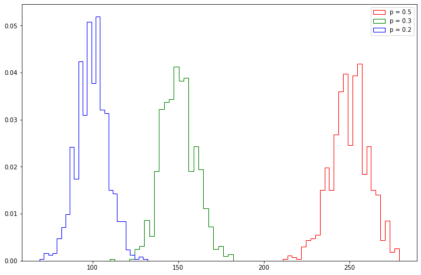

```python
# Sample usage
import matplotlib.pyplot as plt
%matplotlib inline

obs = multinomial_observations(n=500, p=[0.5, 0.3, 0.2], nsim=1000)

plt.figure(figsize=(12, 8))
plt.hist(obs[:, 0], density=True, bins=25, histtype='step', color='red', label='p = 0.5')
plt.hist(obs[:, 1], density=True, bins=25, histtype='step', color='green', label='p = 0.3')
plt.hist(obs[:, 2], density=True, bins=25, histtype='step', color='blue', label='p = 0.2')
plt.legend(loc='upper right')
plt.show()
```

**Exercise 15.6.5 (Computer Experiment)**. Write a function to generate $\text{nsim}$ observations from a Multivariate normal with given mean $\mu$ and covariance matrix $\Sigma$.

**Solution**. Let's construct our samples based on samples of a standard multivariate normal $Z \sim N(0, I)$, by making $X = \mu + \Sigma^{1/2} Z$.

```python
import numpy as np

def multivariate_normal_observations(mu, sigma, nsim=1):
    mu_array = np.array(mu)
    sigma_array = np.array(sigma)

    assert len(mu_array.shape) == 1, "mu should be a vector"
    k = mu_array.shape[0]

    assert sigma_array.shape == (k, k), "sigma should be a square matrix with same length as mu"

    # Do the eigenvalue decomposition, then get U D^{1/2} as Sigma^{1/2}
    U, D, V = np.linalg.svd(sigma_array)
    sigma_sqrt = U @ np.diag(np.sqrt(D))

    # Let's write our own random normal generator for fun, rather than use np.random.normal
    # Strategy: Use Box-Muller to transform two random uniform variables in (0, 1)
    # into two standard normals
    def random_normals(size):

        def box_muller(u1, u2):
            R = np.sqrt(-2 * np.log(u1))
            theta = 2 * np.pi * u2

            z0 = R * np.cos(theta)
            z1 = R * np.sin(theta)

            return z0, z1

        def normal_generator(uniform_generator):
            while True:
                z0, z1 = box_muller(next(uniform_generator), next(uniform_generator))
                yield z0
                yield z1

        def random_generator(batch_size):
            while True:
                for v in np.random.uniform(size=batch_size):
                    yield v

        result = np.empty(size)
        gen = normal_generator(random_generator(batch_size=min(size, 1024)))
        for i in range(size):
            result[i] = next(gen)

        return result

    def get_observation():
        z = random_normals(k)
        return mu_array + sigma_sqrt @ z

    return np.array([get_observation() for _ in range(nsim)])
```

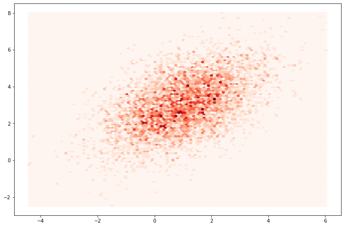

```python
# Sample usage
import matplotlib.pyplot as plt
%matplotlib inline

mu = [1, 3]
sigma = [[2, 1], [1, 2]]
obs = multivariate_normal_observations(mu, sigma, nsim=5000)

plt.figure(figsize=(12, 8))
plt.hexbin(obs[:, 0], obs[:, 1], cmap=plt.cm.Reds)
plt.show()
```

**Exercise 15.6.6 (Computer Experiment)**. Generate 1000 random vectors from a $N(\mu, \Sigma)$ distribution where

$$ \mu = \begin{pmatrix} 3 \\ 8\end{pmatrix} , \quad \Sigma = \begin{pmatrix} 2 & 6 \\ 6 & 2 \end{pmatrix}$$

Plot the simulation as a scatterplot. Find the distribution of $X_2 | X_1 = x_1$ using theorem 15.5. In particular, what is the formula for $\mathbb{E}(X_2 | X_1 = x_1)$? Plot $\mathbb{E}(X_2 | X_1 = x_1)$ on your scatterplot. Find the correlation $\rho$ between $X_1$ and $X_2$. Compare this with the sample correlations from your simulation. Find a 95% confidence interval for $\rho$. Estimate the covariance matrix $\Sigma$.

**Solution**.

$$ \Sigma = \begin{pmatrix} 6 & 2 \\ 2 & 6\end{pmatrix}$$

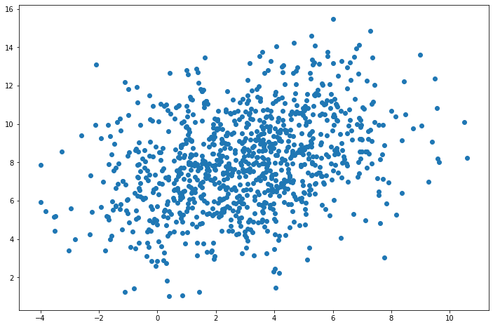

```python
# Generate 1000 vectors
mu = [3, 8]
sigma = [[2, 6], [6, 2]]
obs = multivariate_normal_observations(mu, sigma, nsim=1000)

# Using numpy to generate observations:
#obs = np.random.multivariate_normal(mu, sigma, size=1000)

# Using scipy to generate observations:
#obs = scipy.stats.multivariate_normal.rvs(mean=mu, cov=sigma, size=1000)

x, y = obs[:, 0], obs[:, 1]

# Plot scatterplot
plt.figure(figsize=(12, 8))
plt.scatter(x, y)
plt.show()
```

From theorem 15.5,

$$ X_2 | X_1 = x_1 \sim N(\mu(x_1), \Sigma(x_1))$$

where

$$ \begin{align} \mu(x_1) &= \mu_2 + \Sigma_{21} \Sigma_{11}^{-1} (x_1 - \mu_1) \\ \Sigma(x_1) &= \Sigma_{22} - \Sigma_{21}\Sigma_{11}^{-1}\Sigma_{12} \end{align} $$

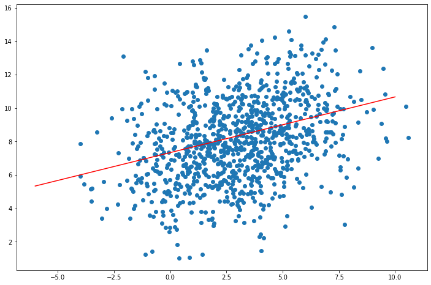

```python
# Plot scatterplot + line
f = lambda x: x/3 + 22/3

plt.figure(figsize=(12, 8))
plt.scatter(x, y)
plt.plot([-6, 10], [f(-6), f(10)], color='red')
plt.show()
```

The correlation $\rho$ between $X_1$ and $X_2$ is:

$$ \rho = \frac{\text{Cov}(X_1, X_2)}{\sigma_{X_1} \sigma_{X_2}} = \frac{1}{3}$$

The estimated correlation $\rho$ between $X_1$ and $X_2$ is:

$$ \hat{\rho} = \frac{\sum_i (X_{1i} - \overline{X}_1)(X_{2i} - \overline{X}_2)}{s_{X_1} s_{X_2}}$$

```python
rho_hat = np.corrcoef(x, y)[0, 1]
print("Estimated correlation: %.3f" % rho_hat)
```

```
Estimated correlation: 0.327
```

We will use the provided process to estimate a confidence interval for the correlation:

**Approximate Confidence Interval for the Correlation**

1. Compute

$$\hat{\theta} = f(\hat{\rho}) = \frac{1}{2} \left( \log(1 + \hat{\rho}) - \log(1 - \hat{\rho})\right) $$

1. Compute the approximate standard error of $\hat{\theta}$ which can be shown to be

$$\hat{\text{se}}(\hat{\theta}) = \frac{1}{\sqrt{n - 3}} $$

1. An approximate $1 - \alpha$ confidence interval for $\theta = f(\rho)$ is

$$(a, b) \equiv \left(\hat{\theta} - \frac{z_{\alpha/2}}{\sqrt{n - 3}}, \; \hat{\theta} + \frac{z_{\alpha/2}}{\sqrt{n - 3}} \right)$$

1. Apply the inverse transformation $f^{-1}(z)$ to get a confidence interval for $\rho$:

$$ \left( \frac{e^{2a} - 1}{e^{2a} + 1}, \frac{e^{2b} - 1}{e^{2b} + 1} \right) $$

```python
from scipy.stats import norm

theta_hat = (np.log(1 + rho_hat) - np.log(1 - rho_hat)) / 2
se_theta_hat = 1 / np.sqrt(1000 - 3)
z = norm.ppf(0.975)
a, b = theta_hat - z * se_theta_hat, theta_hat + z * se_theta_hat
f_inv = lambda x: (np.exp(2*x) - 1) / (np.exp(2*x) + 1)
confidence_interval = (f_inv(a), f_inv(b))

print('95%% confidence interval: %.3f, %.3f' % confidence_interval)
```

```
95% confidence interval: 0.270, 0.381
```

The sample covariance matrix is:

$$ \hat{\Sigma} = \frac{1}{n} S = \frac{1}{n} \sum_{i=1}^n (X_i - \overline{X})(X_i - \overline{X})^T $$

```python
import numpy as np
mu_hat = np.array([x.mean(), y.mean()])
xx = np.concatenate((x.reshape(-1, 1), y.reshape(-1, 1)), axis=1)
sigma_hat = (xx - mu_hat).T @ (xx - mu_hat) / 1000

sigma_hat
```

```
array([[6.17974344, 1.99813879],
       [1.99813879, 6.05196861]])
```

**Exercise 15.6.7 (Computer Experiment)**. Generate 100 random vectors from a multivariate Normal with mean $(0, 2)^T$ and variance

$$ \begin{pmatrix} 1 & 3 \\ 3 & 1 \end{pmatrix} $$

Find a 95% confidence interval for the correlation $\rho$. What is the true value of $\rho$?

**Solution**.

The provided matrix, yet again, has negative eigenvalues. Let's instead use:

$$\Sigma = \begin{pmatrix} 3 & 1 \\ 1 & 3 \end{pmatrix}$$

```python
# Generate 100 vectors
n = 100
mu = [0, 2]
sigma = [[3, 1], [1, 3]]
obs = multivariate_normal_observations(mu, sigma, nsim=n)
x, y = obs[:, 0], obs[:, 1]
```

```python
# Find 95% confidence interval
from scipy.stats import norm

rho_hat = np.corrcoef(x, y)[0, 1]
theta_hat = (np.log(1 + rho_hat) - np.log(1 - rho_hat)) / 2
se_theta_hat = 1 / np.sqrt(n - 3)
z = norm.ppf(0.975)
a, b = theta_hat - z * se_theta_hat, theta_hat + z * se_theta_hat
f_inv = lambda x: (np.exp(2*x) - 1) / (np.exp(2*x) + 1)
confidence_interval = (f_inv(a), f_inv(b))

print('95%% confidence interval: %.3f, %.3f' % confidence_interval)
```

```
95% confidence interval: 0.054, 0.424
```

True value of $\rho$:

$$ \rho = \frac{\text{Cov}(X_1, X_2)}{\sigma_{X_1} \sigma_{X_2}} = \frac{1}{3}$$